# Mortalidad por cáncer de pulmón en Ohio (décadas de 1960 a 1980)

Maria Paula Camargo Rincon**[^1] **Laura Katherine Martínez Castiblanco**[^2]

# Introducción

En la época ya existía evidencia científica respecto al efecto que tenía fumar en el cancer de pulmón, Sin embargo, entre 1978 y 1987, el médico general australiano William Whitby publicó dos libros en los que cuestionaba dicha relación, generando incertidumbre en parte de la población.

El ambiente del cual se rodean las personas significaba bastante pues la exposición del humo de un fumador aumenta el riesgo de cancer de pulmón entre el 10%-30%.

## Pregunta problema

¿En qué medida la tasa de incidencia de cáncer de pulmón en mujeres blancas en 1988 está asociada con las tasas de otros grupos poblacionales, la morfología de la región y los cambios temporales en décadas previas, controlando por población total y casos totales?

## Objetivos:

*General:* Analizar la tasa de incidencia de cáncer de pulmón en las mujeres blancas en 1988 a partir de tasas de otros grupos poblacionales, morfología de la región y los cambios temporales en décadas previas.

*Específicos:*

- Identificar la relación entre las tasas de incidencia de distintos grupos poblacionales de décadas pasadas y la tasa de incidencia de cáncer de pulmón en mujeres blancas en 1988.
- Evaluar la influencia de las características morfológicas regionales en la tasa de incidencia de las mujeres blancas en 1988.
- Analizar los cambios temporales que hubo en la tasa de incidencia de las mujeres blancas en los distintos años.

## Descripción de las variables

La siguiente tabla resume las variables principales de la base de datos:

Definición de variables principales en la base de datos ohlung.shp

| Variable | Descripcion |
| --- | --- |
| CountyID | ID secuencial del condado (orden alfabético) |
| NAME | Nombre del condado |
| FIPSNO | Código FIPS del condado (numérico) |
| AREA | Área del polígono (condado) |
| PERIMETER | Perímetro del polígono (condado) |
| RECORD_ID | ID único del registro |
| COUNTYID | ID del condado |
| LGRyy | Casos de cáncer de pulmón para género G (M/F) y raza R (W/B) en año yy (1968, 1978, 1988) |
| POPGRyy | Población en riesgo para género G y raza R en año yy |
| LGyy | Total de casos de cáncer de pulmón por género G en año yy |
| POPGyy | Población total en riesgo por género G en año yy |

Se realizó una modificación del formato de la tabla para poder trabajar con las variables sexó (Femenino, Masculino), año(1968, 1978, 1988) y raza (Blanco, Negro)

Vista de los datos en formato largo

| NAME | AREA | PERIMETER | gender | race | year | cases | pop |
| --- | --- | --- | --- | --- | --- | --- | --- |
| Adams | 1536060000 | 172801 | Male | White | 1968 | 6 | 8912 |
| Adams | 1536060000 | 172801 | Female | White | 1968 | 0 | 8994 |
| Adams | 1536060000 | 172801 | Male | Black | 1968 | 0 | 24 |
| Adams | 1536060000 | 172801 | Female | Black | 1968 | 0 | 22 |
| Adams | 1536060000 | 172801 | Male | White | 1978 | 7 | 11842 |
| Adams | 1536060000 | 172801 | Female | White | 1978 | 6 | 11996 |
| Adams | 1536060000 | 172801 | Male | Black | 1978 | 0 | 41 |
| Adams | 1536060000 | 172801 | Female | Black | 1978 | 0 | 38 |
| Adams | 1536060000 | 172801 | Male | White | 1988 | 13 | 12443 |
| Adams | 1536060000 | 172801 | Female | White | 1988 | 2 | 12850 |

```
## # A tibble: 1 × 1
##   count
## * <int>
## 1   386
```

Notese que tenemos de 1056 observaciones, 386 son 0 casos, esto puede representar un problema más adelante en los modelos, ya que puede tender a inflar la varianza.

# Exploración descriptiva

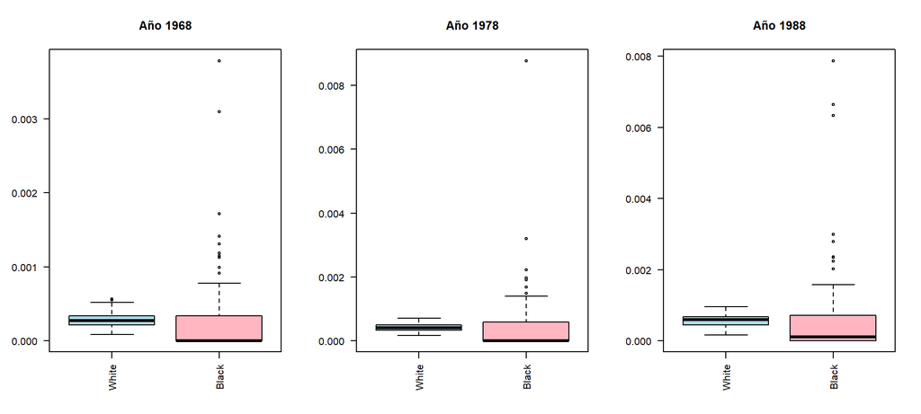

Tasas de incidencia por variable categórica

| categoria | conteo |
| --- | --- |
| Female | 0.1010566 |
| Male | 0.3876166 |
| Black | 0.2652797 |
| White | 0.2233935 |
| 1968 | 0.1017415 |
| 1978 | 0.1636140 |
| 1988 | 0.2233177 |

Podemos evidenciar que a lo largo de los años en la población negra se presenta mayor variación que en la población blanca, además de que se presenta una diferencia notoria en ambos grupos en los 3 años.

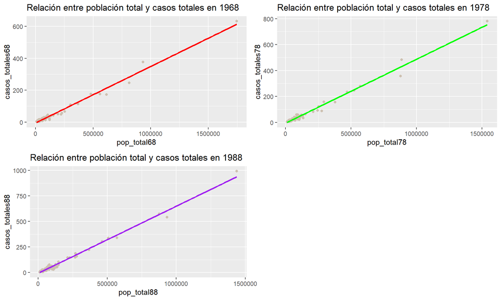

En general los totales de casos y poblaciones en los distintos años se comportan de manera lineal.

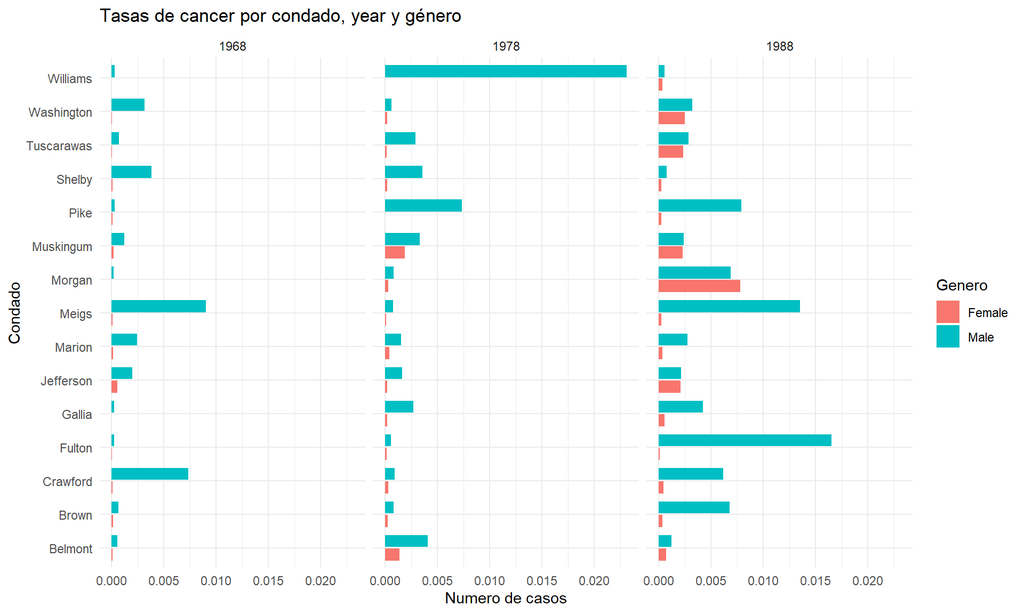

Podemos ver más registros o casos en los hombres que en las mujeres en los distintos años y condados.

Top 15 condados con tasas más altas

| NAME | total_tasas | area |
| --- | --- | --- |
| Williams | 0.0243703 | 1089180000 |
| Meigs | 0.0237038 | 1089800000 |
| Fulton | 0.0176855 | 1054690000 |
| Morgan | 0.0159628 | 1081310000 |
| Pike | 0.0159304 | 1128210000 |
| Crawford | 0.0152284 | 1013780000 |
| Muskingum | 0.0112092 | 1722120000 |
| Washington | 0.0097122 | 1626890000 |
| Tuscarawas | 0.0090480 | 1488060000 |
| Brown | 0.0089926 | 1272420000 |
| Shelby | 0.0086664 | 1049430000 |
| Jefferson | 0.0085801 | 1032610000 |
| Belmont | 0.0080245 | 1387480000 |
| Gallia | 0.0079639 | 1230960000 |
| Marion | 0.0076424 | 1036070000 |

# Exploración espacial

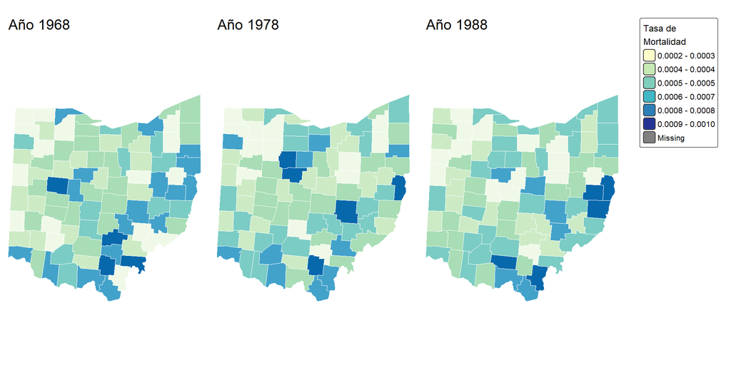

Podemos ver que en los años se ha presentado un aumento de la tasa de incidencia de cancer de pulmón.

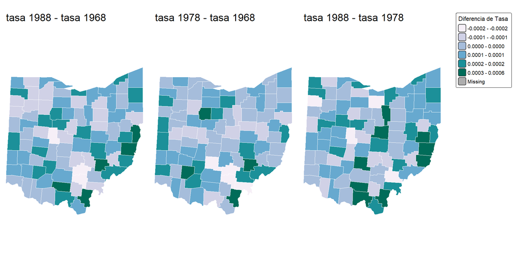

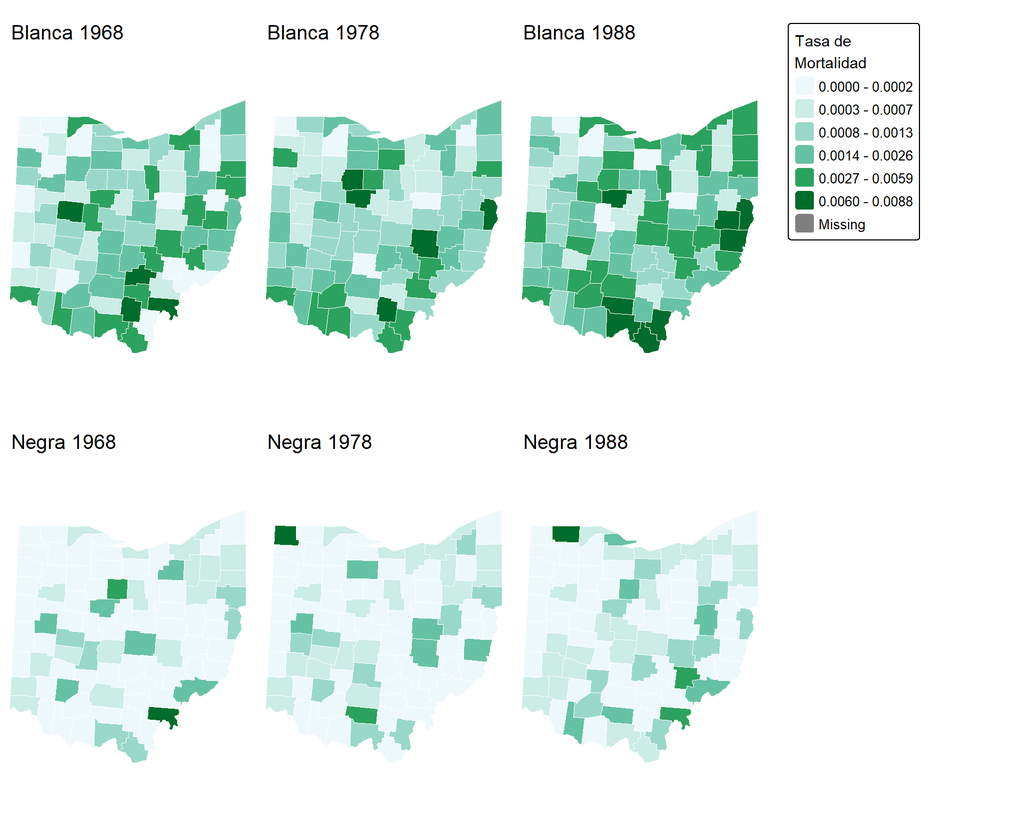

En general se ve un aumento en las tasas de cancer de pulmón, más notoriamente en la población de blancos que en la población de negros.

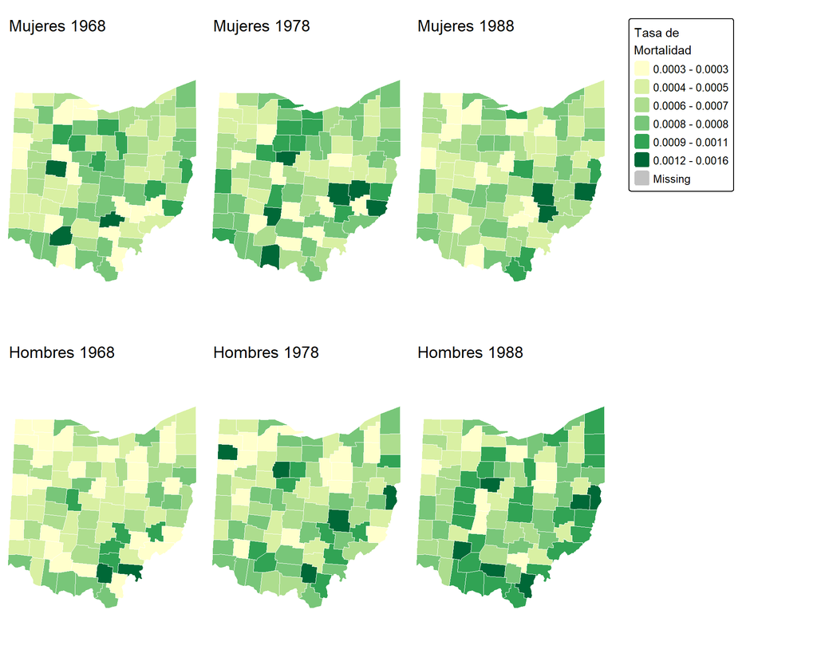

Podemos ver que en ambos grupos se presenta variación a través de los condados, además de esto los hombres presentan tasas más altas de cancer de pulmón, las cuales aumentan conforme pasan los años.

Top 1–10

| Var. A | Var. B | r |
| --- | --- | --- |
| pop_total68 | POPF68 | 1.000 |
| pop_total68 | POPM68 | 1.000 |
| pop_total78 | POPF78 | 1.000 |
| pop_total78 | POPM78 | 1.000 |
| pop_total88 | POPF88 | 1.000 |
| pop_total88 | POPM88 | 1.000 |
| POPFW68 | POPMW68 | 1.000 |
| POPF68 | POPM68 | 1.000 |
| POPFW78 | POPMW78 | 1.000 |
| POPFB68 | POPMB68 | 1.000 |
| POPFB78 | POPMB78 | 1.000 |
| POPF78 | POPM78 | 1.000 |
| POPFW88 | POPMW88 | 1.000 |
| POPF88 | POPM88 | 1.000 |
| POPFB88 | POPMB88 | 1.000 |
| POPFB88 | POPMB78 | 1.000 |
| casos_totales68 | LM68 | 0.999 |
| LM68 | LMW68 | 0.999 |
| POPFB78 | POPFB88 | 0.999 |
| POPMB78 | POPMB88 | 0.999 |

Top 11–20

| Var. A | Var. B | r |
| --- | --- | --- |
| POPFW68 | POPM68 | 0.999 |
| POPF88 | POPM78 | 0.999 |
| pop_total68 | POPFW68 | 0.999 |
| casos_totales78 | LM78 | 0.999 |
| LF78 | LFW78 | 0.999 |
| casos_totales88 | LM88 | 0.999 |
| POPM68 | POPMW68 | 0.999 |
| pop_total78 | POPF88 | 0.999 |
| POPF68 | POPFW68 | 0.999 |
| POPFW78 | POPM78 | 0.999 |
| POPF78 | POPFW68 | 0.999 |
| pop_total88 | POPM78 | 0.999 |
| POPF78 | POPMW68 | 0.999 |
| casos_totales68 | LMW68 | 0.999 |
| POPFB78 | POPMB88 | 0.999 |
| pop_total78 | POPMW68 | 0.999 |
| pop_total68 | POPMW68 | 0.998 |
| pop_total78 | POPFW68 | 0.998 |
| POPF78 | POPF88 | 0.998 |
| POPF88 | POPFW78 | 0.998 |

Top 21–30

| Var. A | Var. B | r |
| --- | --- | --- |
| pop_total88 | POPFW78 | 0.998 |
| POPM78 | POPMW68 | 0.998 |
| pop_total78 | pop_total88 | 0.998 |
| pop_total78 | POPFW78 | 0.998 |
| POPFW88 | POPMW78 | 0.998 |
| POPFB78 | POPMB68 | 0.998 |
| POPM78 | POPM88 | 0.998 |
| POPFW78 | POPM88 | 0.998 |
| POPM88 | POPMW78 | 0.998 |
| POPF68 | POPMW68 | 0.998 |
| pop_total88 | POPMW78 | 0.998 |
| POPFW68 | POPM78 | 0.998 |
| POPM78 | POPMW78 | 0.998 |
| POPF88 | POPMW78 | 0.998 |
| POPFB68 | POPFB78 | 0.998 |
| pop_total88 | POPF78 | 0.998 |
| POPF78 | POPFW78 | 0.998 |
| LM78 | LMW78 | 0.998 |
| pop_total78 | POPM88 | 0.998 |
| POPFW88 | POPM88 | 0.998 |

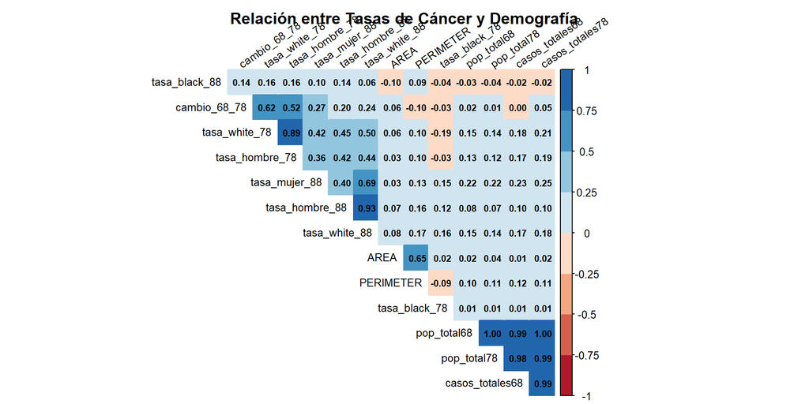

En cuanto a la variable respuesta, esta presenta correlaciones altas moderadas con las variables *tasa_hombre_88* y *tasa_white_88*.

## Selección de Variables

Para modelar los datos de área de forma adecuada, la estructura del modelo debe seguir una lógica epidemiológica de conteo:

## Evaluación y Selección de la Matriz $W$

La elección de $W$ no es arbitraria; se debe seleccionar aquella que maximice la captura de la dependencia espacial en los datos de 1988.

Según el sustento teórico, la matriz de pesos puede basarse en la similitud de una variable $X$ altamente relacionada con la respuesta $Z$. Para esto, definimos $w_{ij} = 1/(x_i - x_j)$, donde $x$ es la variable con mayor correlación con la tasa de cáncer de 1988.

Se evalúan cuatro tipos de estructuras:

- **Contigüidad Física:** Rook (Torre) y Queen (Reina).
- **Basadas en Distancia:** $k$-vecinos más cercanos con $k=3,4,5, 6,7, 8, 9, 10$.
- **Basada en Atributos:** Ponderación por diferencia de tasas históricas (similitud epidemiológica).

```
##             Matriz    Moran_I      p_valor
## 14 Variable_Weight 0.25824080 9.513234e-07
## 8             KNN5 0.06875205 2.039833e-01
## 12            KNN9 0.03099310 3.504583e-01
## 7             KNN4 0.05342814 3.577762e-01
## 9             KNN6 0.04043957 3.635502e-01
## 10            KNN7 0.02722859 4.601030e-01
## 11            KNN8 0.02270906 4.816267e-01
## 6             KNN3 0.04268369 5.052026e-01
## 1        Insumo.lw 0.02760245 5.483440e-01
## 5       Insumo.lww 0.02760245 5.483440e-01
## 3       Insumo.lwc 0.02579689 5.562978e-01
## 2       Insumo.lwb 0.02579689 5.562978e-01
## 4       Insumo.lwu 0.02579689 5.562978e-01
## 13           KNN10 0.01278658 5.724002e-01
```

```
##
##  Moran I test under randomisation
##
## data:  ohlung$tasa_mujer_88
## weights: W_seleccionada
##
## Moran I statistic standard deviate = 4.9014, p-value = 9.513e-07
## alternative hypothesis: two.sided
## sample estimates:
## Moran I statistic       Expectation          Variance
##       0.258240797      -0.011494253       0.003028488
```

El Test de Moran Global confirma la existencia de una fuerte autocorrelación espacial positiva en la tasa de cáncer de pulmón en mujeres para 1988 (I = 0.258; p-valor < 0.0001). Este resultado demuestra que la enfermedad no se distribuye de forma aleatoria en Ohio, sino que forma clústeres significativos. La intensidad de este índice, mayor a la observada en otros grupos demográficos, sugiere que los factores de riesgo subyacentes tienen una marcada estructura geoespacial o socio-ambiental.

[figure not shown]

## 1. Comparación Estructural y Topológica

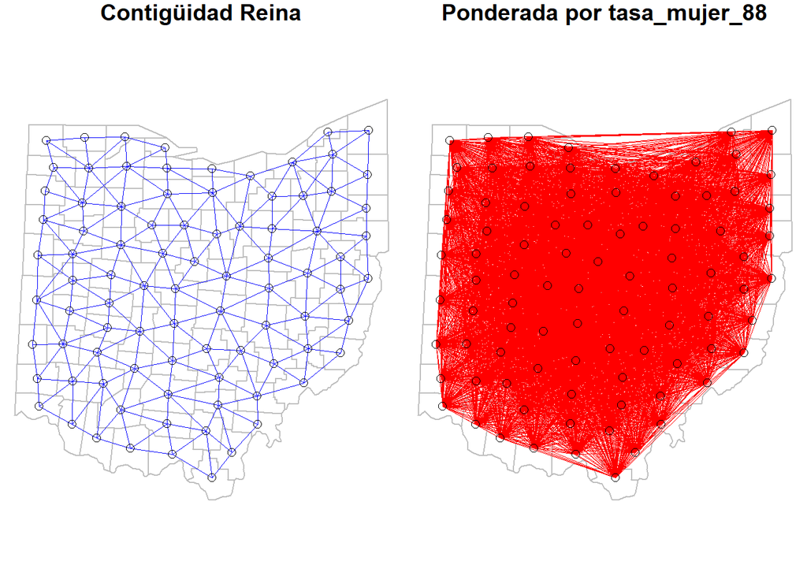

## 2. Diagrama de Dispersión de Moran (Moran Scatterplot)

Este gráfico visualiza la relación entre el valor de la tasa en un condado ($z_i$) y el promedio ponderado de sus vecinos ($\sum c_{ij}z_j$). * **Cuadrantes I y III:** Representan autocorrelación espacial positiva (Hotspots y Coldspots). * **Cuadrantes II y IV:** Representan autocorrelación negativa (Atípicos espaciales).

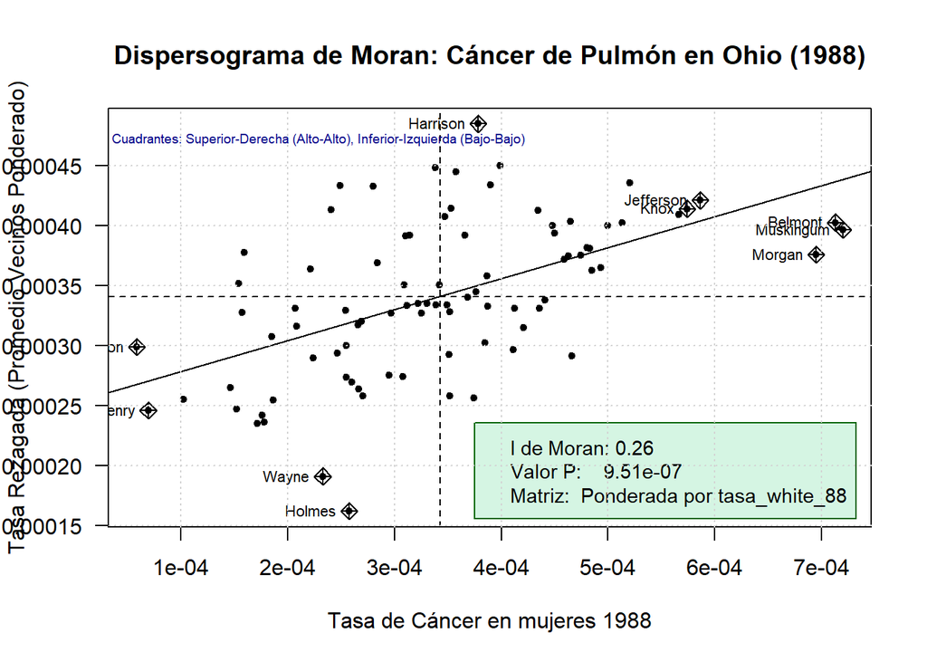

## 3. Exploración de Promedios Móviles Espaciales

La matriz $W$ actúa como un **operador de rezago espacial**. Al calcular el promedio ponderado de los vecinos, suavizamos la variable para detectar tendencias regionales de largo alcance en lugar de ruido local.

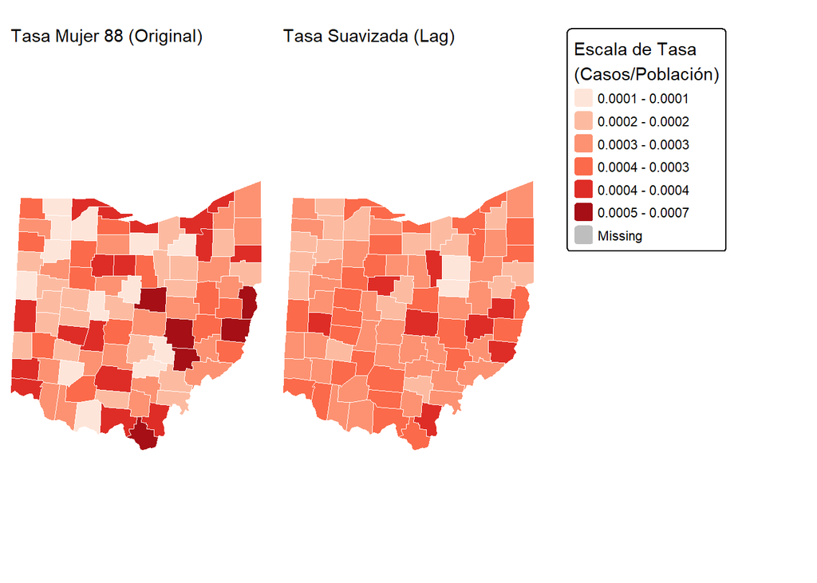

La comparación bajo una escala unificada demuestra que, al eliminar el ruido estadístico local mediante el rezago espacial (Lag), persiste una estructura regional de alta incidencia de cáncer de pulmón en mujeres en el sudeste de Ohio.

# Modelo final

## Modelo Lag

```r
glmlag_knn8 <- glm(LF88  ~ tasa_hombre_68 + tasa_hombre_78  +  tasa_hombre_88  +tasa_white_88 +
                     lag_LF88+lag_POPF88,
                   offset = log(POPF88),
            data=Y_ext_knn8,family = poisson(link = "log"))
summary(glmlag_knn8)
```

```
##
## Call:
## glm(formula = LF88 ~ tasa_hombre_68 + tasa_hombre_78 + tasa_hombre_88 +
##     tasa_white_88 + lag_LF88 + lag_POPF88, family = poisson(link = "log"),
##     data = Y_ext_knn8, offset = log(POPF88))
##
## Coefficients:
##                  Estimate Std. Error z value Pr(>|z|)
## (Intercept)    -9.071e+00  1.669e-01 -54.344  < 2e-16 ***
## tasa_hombre_68  1.227e+02  2.115e+02   0.580    0.562
## tasa_hombre_78  2.025e+02  1.801e+02   1.124    0.261
## tasa_hombre_88 -2.234e+03  3.298e+02  -6.776 1.24e-11 ***
## tasa_white_88   4.591e+03  5.193e+02   8.842  < 2e-16 ***
## lag_LF88        1.311e-03  9.041e-03   0.145    0.885
## lag_POPF88      2.161e-07  4.139e-06   0.052    0.958
## ---
## Signif. codes:  0 '***' 0.001 '**' 0.01 '*' 0.05 '.' 0.1 ' ' 1
##
## (Dispersion parameter for poisson family taken to be 1)
##
##     Null deviance: 175.292  on 87  degrees of freedom
## Residual deviance:  16.312  on 81  degrees of freedom
## AIC: 400.06
##
## Number of Fisher Scoring iterations: 4
```

### *Independecia*

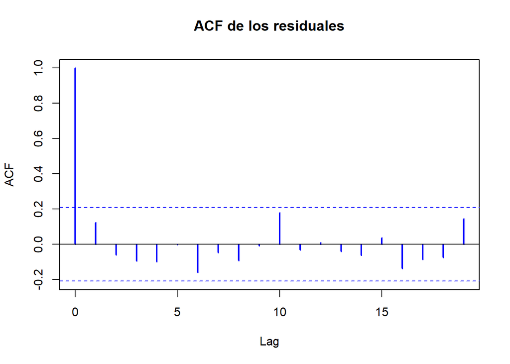

```r
acf(residuals.glm(glmlag_knn8), main = "ACF de los residuales", col = "blue", lwd = 2)
```

El correlograma muestra que no parece haber una correlación fuerte en los residuales, sin embargo, se decidió hacer una verificación más formal del supuesto de independencia en los errores, usando la prueba de Durbin Watson

```r
dwtest(glmlag_knn8)
```

```
##
##  Durbin-Watson test
##
## data:  glmlag_knn8
## DW = 2.1365, p-value = 0.7281
## alternative hypothesis: true autocorrelation is greater than 0
```

```r
moran.test(residuals.glm(glmlag_knn8),W_seleccionada)
```

```
##
##  Moran I test under randomisation
##
## data:  residuals.glm(glmlag_knn8)
## weights: W_seleccionada
##
## Moran I statistic standard deviate = 0.65452, p-value = 0.2564
## alternative hypothesis: greater
## sample estimates:
## Moran I statistic       Expectation          Variance
##       0.024322966      -0.011494253       0.002994634
```

Se aplico un test de moran para verificar que dentro de los residuales no hubiera dependencia espacial, ya que durbin watson identifica más una dependencia temporal. El resultado de esta prueba es un p valor mayor al nivel de significancia ($\alpha=0.05$), por lo que no se rechaza la $H_0$ de independecia espacial.

### *Normalidad*

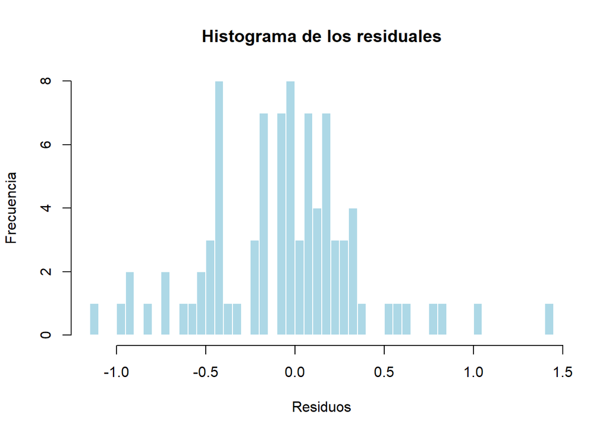

```r
hist(residuals.glm(glmlag_knn8),breaks = 50, main = "Histograma de los residuales", xlab = "Residuos", ylab = "Frecuencia", col = "lightblue", border = "white")
```

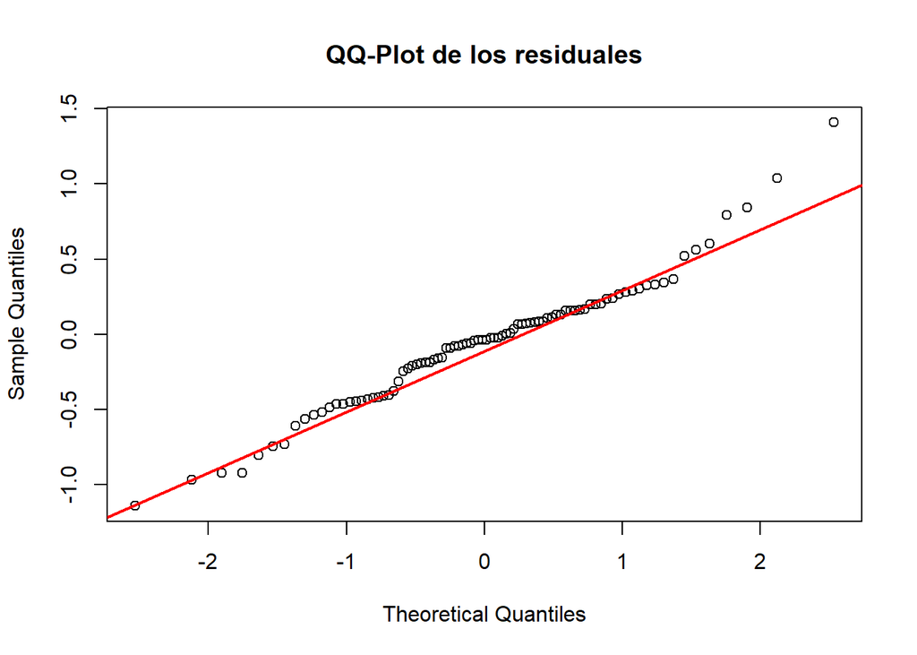

```r
qqnorm(residuals.glm(glmlag_knn8), main = "QQ-Plot de los residuales")
qqline(residuals.glm(glmlag_knn8), col = "red", lwd = 2)
```

El histograma y el qqplot no son claros pues parece haber simetría, y la mayoría de los puntos estan alrededor de la línea, presentando un poco de problemas en las colas.

Para confirmar si la distribución es o no normal se decidió hacer la prueba de $Shapiro-Wilk$

```r
shapiro.test(residuals.glm(glmlag_knn8))
```

```
##
##  Shapiro-Wilk normality test
##
## data:  residuals.glm(glmlag_knn8)
## W = 0.97093, p-value = 0.04504
```

### *Homocedasticidad*

Para evaluar la heteroscedasticidad formalmente, tomando en cuenta que la población no sigue o proviene de una distrincuón normal, se decidió aplicar el test de Breusch-pagan.

```
##
##  studentized Breusch-Pagan test
##
## data:  glmlag_knn8
## BP = 4.6415, df = 6, p-value = 0.5905
```

Al ser mucho mayor a 0.05, no se rechaza la hipótesis nula de que la varianza es constante.

#### Verificación de Sobredispersión

Si el parámetro de dispersión es mucho mayor a 1, el modelo Poisson estándar podría estar subestimando los errores estándar.

```r
check_overdispersion(glmlag_knn8)
```

```
## # Overdispersion test
##
##        dispersion ratio =  0.195
##   Pearson's Chi-Squared = 15.775
##                 p-value =      1
```

```
## No overdispersion detected.
```

```r
# Test simple de sobredispersión (Ratio Chi-cuadrado / Grados de libertad)
dispersion_ratio <- glmlag_knn8$deviance / glmlag_knn8$df.residual
cat("Ratio de dispersión:", dispersion_ratio, "\n")
```

```
## Ratio de dispersión: 0.2013857
```

```r
# Si el ratio > 1.2-1.5, considera Quasi-Poisson o Binomial Negativa
```

El modelo no parece presentar sobredispersión.

# Selección del mejor modelo

Para seleccionar el mejor modelo realizamos el siguiente procedimiento:

```r
library(DiagrammeR)

grViz("
digraph modelo {

  graph [
    layout = dot,
    rankdir = TB,
    nodesep = 0.6,
    ranksep = 0.8
  ]

  edge [splines = ortho]

  node [
    shape = rectangle,
    style = 'rounded, filled',
    fillcolor = lightblue
  ]

  # Decisiones (rombos)
  homoc [label = '¿Homoscedasticidad?', shape = diamond]
  indep [label = '¿Independencia?', shape = diamond]
  norm  [label = '¿Normalidad?', shape = diamond]
  beta  [label = '¿Algún beta significativo?', shape = diamond]

  # Procesos
  inicio [label = 'Modelo candidato']
  cv     [label = 'LOOCV (n = 88)']
  rss    [label = 'Comparar RSS']
  mejor  [label = 'Mejor modelo', shape = oval, fillcolor = chartreuse3]

  # Columna derecha (descartar)
  desc1 [label = 'Descartar modelo', fillcolor = lightcoral]
  desc2 [label = 'Descartar modelo', fillcolor = lightcoral]
  desc3 [label = 'Descartar modelo', fillcolor = lightcoral]
  desc4 [label = 'Descartar modelo', fillcolor = lightcoral]

  # --- COLUMNAS ---
  { rank = same; homoc; desc1 }
  { rank = same; indep; desc2 }
  { rank = same; norm;  desc3 }
  { rank = same; beta;  desc4 }

  # Flujo principal (columna izquierda)
  inicio -> homoc
  homoc -> indep [label = 'Sí']
  indep -> norm  [label = 'Sí']
  norm  -> beta  [label = 'Sí']
  beta  -> cv    [label = 'Sí']
  cv -> rss -> mejor

  # Conexiones a columna derecha (NO)
  homoc -> desc1 [label = 'No']
  indep -> desc2 [label = 'No']
  norm  -> desc3 [label = 'No']
  beta  -> desc4 [label = 'No']
}
")
```

[interactive chart not shown]

## Comparación de Modelos Aspaciales y Espaciales

Dado que los modelos de la familia quasipoisson no proporcionan un AIC estándar, implementamos una función para calcular el *QAIC* y comparamos la *Razón de Dispersión (Devianza)* y la *Autocorrelación (Moran)* entre los modelos ajustados.

```r
library(performance)
library(knitr)

# 1. Función para calcular QAIC manualmente
# Nota: Usamos el logLik del modelo Poisson base y la dispersión del Quasi
calcular_qaic <- function(modelo_quasi, modelo_poisson_base) {
  phi <- summary(modelo_quasi)$dispersion
  ll <- as.numeric(logLik(modelo_poisson_base))
  k <- length(coef(modelo_quasi))
  return(-2 * ll / phi + 2 * k)
}

# Función para calcular QBIC (análogo al BIC para modelos Quasi)
calcular_qbic <- function(modelo_quasi, modelo_poisson_base) {
  phi <- summary(modelo_quasi)$dispersion
  ll <- as.numeric(logLik(modelo_poisson_base))
  k <- length(coef(modelo_quasi))
  n <- length(residuals(modelo_quasi))
  return(-2 * ll / phi + k * log(n))
}

# 2. Extracción de Razón de Dispersión y Moran
get_diag <- function(modelo, w_mat) {
  res <- residuals(modelo, type = "pearson")
  m_test <- moran.test(res, w_mat, zero.policy = TRUE)
  ratio <- sum(res^2) / df.residual(modelo)
  return(list(ratio = ratio, moran_p = m_test$p.value))
}

# 3. Construcción de la Tabla Comparativa
modelos_nombres <- c("MCO (Normal)", "Poisson Final", "Quasi-Poisson", "Poisson MESF", "Modelo LSX", 'Modelo lag', 'Modelo lag XY')

tab_comp <- data.frame(
  Modelo = modelos_nombres,

  # AIC / QAIC
  AIC_QAIC = c(
    AIC(mco_final),
    AIC(poisson_final),
    calcular_qaic(qpoisson_final, poisson_final),
    AIC(fit_poisson_espacial),
    AIC(glmLSX_knn8),
    AIC(glmlag_knn8),
    AIC(glmlagXY)
  ),

  # BIC / QBIC
  BIC_QBIC = c(
    BIC(mco_final),
    BIC(poisson_final),
    calcular_qbic(qpoisson_final, poisson_final),
    BIC(fit_poisson_espacial),
    BIC(glmLSX_knn8),
    BIC(glmlag_knn8),
    BIC(glmlagXY)
  ),

  # Log-Likelihood (Pura medida de ajuste)
  LogLik = c(
    logLik(mco_final),
    logLik(poisson_final),
    NA, # Quasi-modelos no tienen LogLik real
    logLik(fit_poisson_espacial),
    logLik(glmLSX_knn8),
    logLik(glmlag_knn8),
    logLik(glmlagXY)
  ),

  Dispersion_Ratio = c(
    NA, # MCO no aplica ratio de conteo
    check_overdispersion(poisson_final)$dispersion_ratio,
    summary(qpoisson_final)$dispersion,
    check_overdispersion(fit_poisson_espacial)$dispersion_ratio,
    check_overdispersion(glmLSX_knn8)$dispersion_ratio,
    check_overdispersion(glmlag_knn8)$dispersion_ratio,
    check_overdispersion(glmlagXY)$dispersion_ratio
  ),

  Moran_p_value = c(
    get_diag(mco_final, W_seleccionada)$moran_p,
    get_diag(poisson_final, W_seleccionada)$moran_p,
    get_diag(qpoisson_final, W_seleccionada)$moran_p,
    get_diag(fit_poisson_espacial, W_seleccionada)$moran_p,
    get_diag(glmLSX_knn8,W_seleccionada)$moran_p,
    get_diag(glmlag_knn8,W_seleccionada)$moran_p,
    get_diag(glmlagXY,W_seleccionada)$moran_p
  )
)

knitr::kable(tab_comp, digits = 4, caption = "Comparativa de Criterios de Información y Diagnóstico Espacial")
```

Comparativa de Criterios de Información y Diagnóstico Espacial

| Modelo | AIC_QAIC | BIC_QBIC | LogLik | Dispersion_Ratio | Moran_p_value |
| --- | --- | --- | --- | --- | --- |
| MCO (Normal) | -1406.8914 | -1394.5048 | 708.4457 | NA | 0.2707 |
| Poisson Final | 491.3670 | 498.7990 | -242.6835 | 1.2839 | 0.0096 |
| Quasi-Poisson | 374.7653 | 379.7200 | NA | 1.3091 | 0.0202 |
| Poisson MESF | 481.6962 | 494.0829 | -235.8481 | 1.1461 | 0.0658 |
| Modelo LSX | 403.9368 | 426.2329 | -192.9684 | 0.1982 | 0.5950 |
| Modelo lag | 400.0603 | 417.4016 | -193.0301 | 0.1947 | 0.2495 |
| Modelo lag XY | 458.1431 | 475.4844 | -222.0715 | 0.8636 | 0.2119 |

[^1]: mcamargori@unal.edu.co
[^2]: laumartinezca@unal.edu.co